# First Pandas HW

I am showing you my results for the the homework. I am not showing any of the code. That is for you to figure out. Everplace you see "out" you will know there was a code cell.

# Q1

Read in the Fall2025ClassList.xlsx with sheet 'class list' and set the index to uni.  
Then look at your uni to find you what you will analyze with WellData. We will use this again on future homeworks.

```
Name            Mailloux, Brian
WellData                  Drink
NYCTree              root_other
Core#                 18NYHC044
Poster Group                  4
Name: bjm2103, dtype: object
```

State what you will analyze. I am looking at the parameter drink. NO ONE in the class will analyze drink. You will use one of the other columns

# Q2

Read in the well data EXCEL! Print columns and make a boxplot of Arsenic split up by your parameter. Don't forget to label your y-axis and add a figure caption

```
Index(['Well_ID', 'Lat', 'Lon', 'Depth', 'Drink', 'Aquifer', 'Shared', 'Pump',
       'Platform', 'Si', 'P', 'S', 'Ca', 'Fe', 'Ba', 'Na', 'Mg', 'K', 'Mn',
       'As', 'Sr', 'F', 'Cl', 'SO4', 'Br'],
      dtype='object')
```

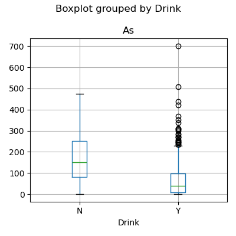

# Q3

Use value counts to see how the values of your paramter. Describe in one sentence.

```
Drink
Y    614
N    144
Name: count, dtype: int64
```

# Q4

Use groupby and describe to summarize the arsenic compared to your parameter. Compare in 1-2 sentences

| Drink | count | mean | std | min | 25% | 50% | 75% | max |
| --- | --- | --- | --- | --- | --- | --- | --- | --- |
| N | 71.0 | 171.105792 | 107.308224 | 1.368709 | 81.614239 | 150.250 | 250.245000 | 473.34 |
| Y | 336.0 | 72.484421 | 91.571489 | 0.000000 | 9.962403 | 39.975 | 99.294435 | 700.89 |

# Q5

Use a t-tetst to see if the mean arsenic concentrations between your groups are signifcant. Say in 1 sentence if signicant or not and at what level.

```
TtestResult(statistic=-7.209206229150192, pvalue=1.48295794648615e-10, df=92.74138989735245)
```

# Q6

Plot Arsenic versus depth. Add a 1 sentence figure caption. You will need to search how to invert your y-axis (depth always goes down) and how to get the ticks and labels to the top. Inverting is an easy search. For the next part you need to search how to do labels and how to do ticks.

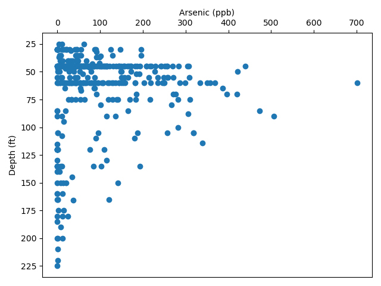

# Q7

Plot arsenic Versus Depth colored by your parameter. Choose your favorite colors. Add a 1 sentence figure caption. Some hints. Copy your plot from above. But now you will call scatter twice. Once for each value of your parameter. You know from the packet how to look at a subset of the data. Make sure you do that for both depth and arsenic. add the labels. add the color. then add the legend.

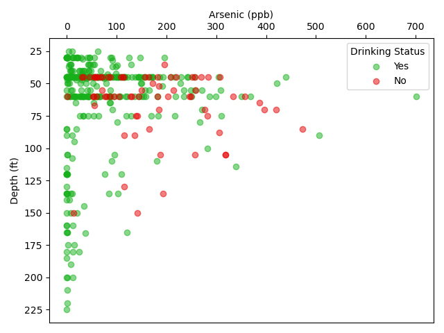

[output not shown]